# Stats Final Project-Slide

Siddharth Gowda

6/3/2020

# NFL Stats Project in R

## Introduction

What is R?

# Was there a correlation between a teams strength of schedule and their win percentage in the 2019 NFL season?

```r
AFC = read.csv("AFC_Data.csv")
NFC = read.csv("NFC_Data.csv")
head(AFC)
```

```
##                      Tm  W  L T  W.L.  PF  PA   PD   MoV  SoS   SRS OSRS DSRS
## 1 New England Patriots* 12  4 0 0.750 420 225  195  12.2 -1.8  10.4  2.8  7.6
## 2        Buffalo Bills+ 10  6 0 0.625 314 259   55   3.4 -1.3   2.2 -3.5  5.7
## 3         New York Jets  7  9 0 0.438 276 359  -83  -5.2 -1.1  -6.3 -5.7 -0.6
## 4        Miami Dolphins  5 11 0 0.313 306 494 -188 -11.8  0.2 -11.6 -2.4 -9.1
## 5     Baltimore Ravens* 14  2 0 0.875 531 282  249  15.6  0.1  15.6 11.0  4.7
## 6   Pittsburgh Steelers  8  8 0 0.500 289 303  -14  -0.9  1.2   0.3 -4.3  4.6
```

```r
head(NFC)
```

```
##                     Tm  W  L T  W.L.  PF  PA   PD   MoV  SoS   SRS OSRS DSRS
## 1 Philadelphia Eagles*  9  7 0 0.563 385 354   31   1.9 -1.7   0.3  0.7 -0.4
## 2       Dallas Cowboys  8  8 0 0.500 434 321  113   7.1 -1.8   5.3  3.8  1.5
## 3      New York Giants  4 12 0 0.250 341 451 -110  -6.9 -1.0  -7.9 -1.8 -6.1
## 4  Washington Redskins  3 13 0 0.188 266 435 -169 -10.6 -0.2 -10.8 -6.3 -4.5
## 5   Green Bay Packers* 13  3 0 0.813 376 313   63   3.9 -0.7   3.2  0.6  2.6
## 6   Minnesota Vikings+ 10  6 0 0.625 407 303  104   6.5 -1.1   5.4  2.5  2.9
```

```r
NFL = rbind(AFC, NFC)
tail(NFL)
```

```
##                      Tm  W  L T  W.L.  PF  PA   PD  MoV  SoS  SRS OSRS DSRS
## 27 Tampa Bay Buccaneers  7  9 0 0.438 458 449    9  0.6 -0.2  0.4  4.9 -4.5
## 28    Carolina Panthers  5 11 0 0.313 340 470 -130 -8.1  1.1 -7.0 -1.9 -5.1
## 29 San Francisco 49ers* 13  3 0 0.813 479 310  169 10.6  0.4 11.0  6.7  4.3
## 30    Seattle Seahawks+ 11  5 0 0.688 405 398    7  0.4  2.3  2.7  2.9 -0.2
## 31     Los Angeles Rams  9  7 0 0.563 394 364   30  1.9  2.0  3.9  2.2  1.7
## 32    Arizona Cardinals  5 10 1 0.344 361 442  -81 -5.1  1.8 -3.2 -0.3 -2.9
```

Just loaded and combined the NFC and AFC datasets/dataframes into one set (from Pro Football Reference and converted into csv)

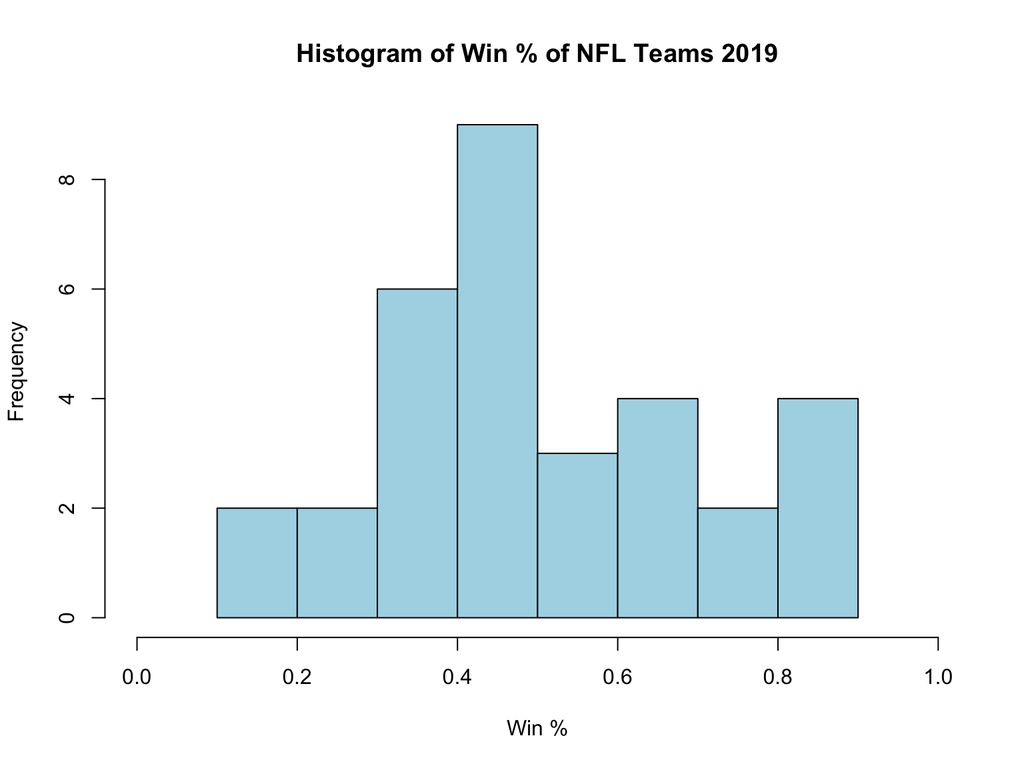

```r
hist(NFL$W.L., main = "Histogram of Win % of NFL Teams 2019",
     xlab = "Win %",
     col = "Light Blue", xlim = c(0,1))
```

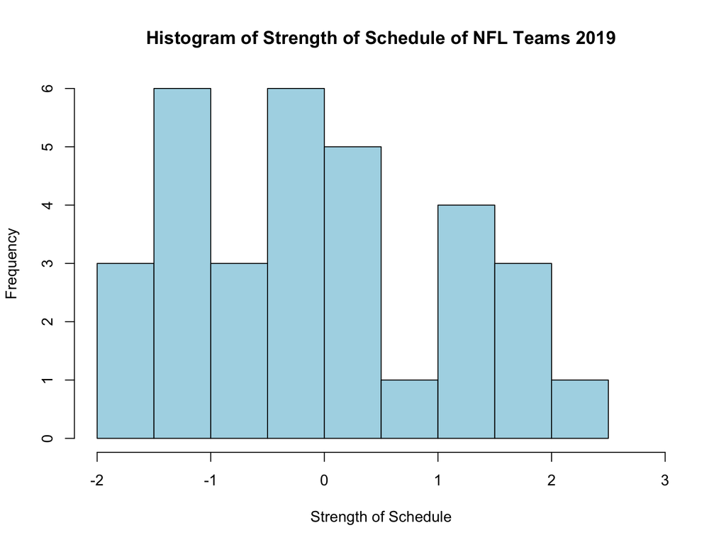

```r
hist(NFL$SoS, main = "Histogram of Strength of Schedule of NFL Teams 2019",
     xlab = "Strength of Schedule", col = "Light Blue", xlim = c(-2,3))
```

Strength of schedule?

Win percentage?

W.L. = Win percentage SoS = Strength of schedule

Why did I plot a histogram: I wanted to see the distribution of the two variables and if there were apparent outliers and had a somewhat normal or symmetric distribution.

```r
#Linear Regression
NFL_WLSoS = lm(NFL$W.L. ~ NFL$SoS)
summary(NFL_WLSoS)
```

```
##
## Call:
## lm(formula = NFL$W.L. ~ NFL$SoS)
##
## Residuals:
##      Min       1Q   Median       3Q      Max
## -0.34331 -0.12295 -0.03874  0.11552  0.37685
##
## Coefficients:
##             Estimate Std. Error t value Pr(>|t|)
## (Intercept)  0.50028    0.03532  14.162 7.99e-15 ***
## NFL$SoS     -0.02131    0.03114  -0.684    0.499
## ---
## Signif. codes:  0 '***' 0.001 '**' 0.01 '*' 0.05 '.' 0.1 ' ' 1
##
## Residual standard error: 0.1998 on 30 degrees of freedom
## Multiple R-squared:  0.01538,    Adjusted R-squared:  -0.01744
## F-statistic: 0.4685 on 1 and 30 DF,  p-value: 0.4989
```

Since the p-value (0.4989) is greater than alpha = 0.05 we fail to reject the null hypothesis. At alpha = 0.05 there is no significant evidence that there is a linear relationship between the strength of schedule and the win percentage of an NFL team in 2019. However, these calculations provide some evidence to the motto “any given Sunday” because the lack of evidence for a linear relationships suggests that perhaps upset occur frequently in the NFL. This is a question that I would investigate further if I had more time.

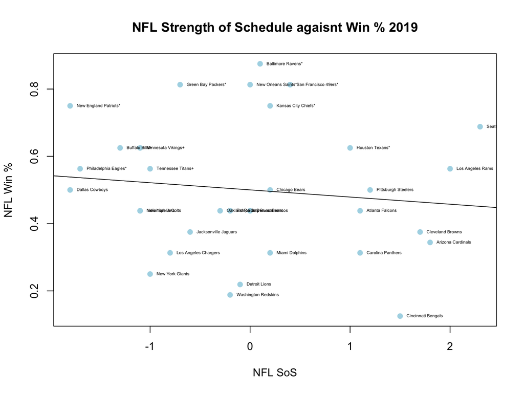

```r
plot(NFL$SoS, NFL$W.L.,
     xlab = "NFL SoS",
     ylab = "NFL Win %",
     main = "NFL Strength of Schedule agaisnt Win % 2019",
     pch = 19,
     col = "light blue")
with(NFL, text(NFL$W.L. ~ NFL$SoS,
               labels=Tm,
               pos=4,
               cex=.4))
abline(NFL_WLSoS)
```

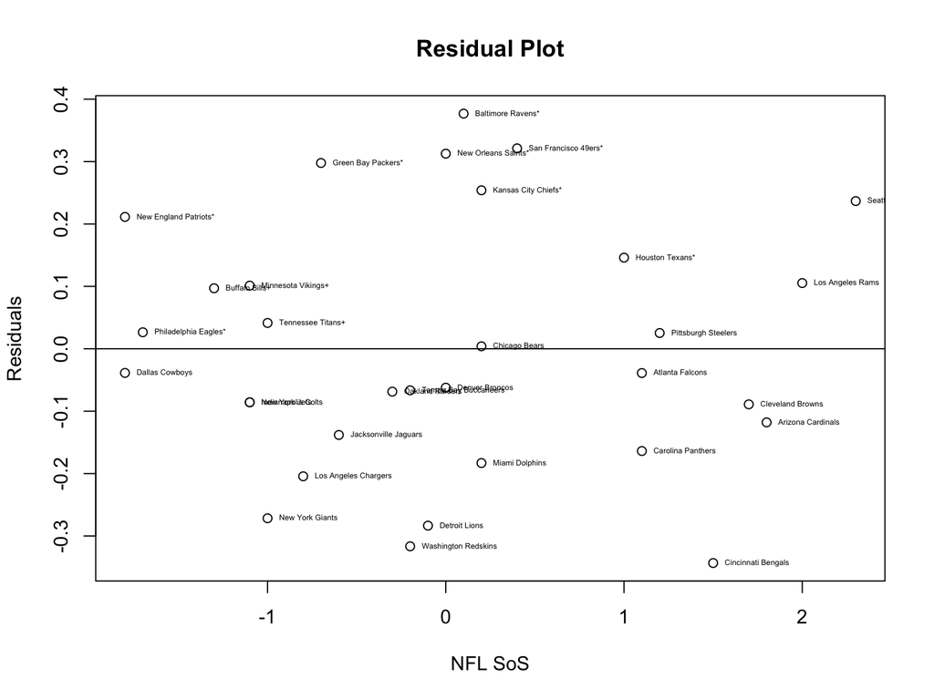

```r
res_NFL_WLSoS = residuals(NFL_WLSoS)
plot(NFL$SoS, res_NFL_WLSoS, main = "Residual Plot", xlab = "NFL SoS", ylab = "Residuals")
with(NFL, text(res_NFL_WLSoS ~ NFL$SoS, labels=Tm, pos=4, cex=.4))
abline(h = 0)
```

# Was there a correlation between the win percentage of a NFL team and their point differential in 2019?

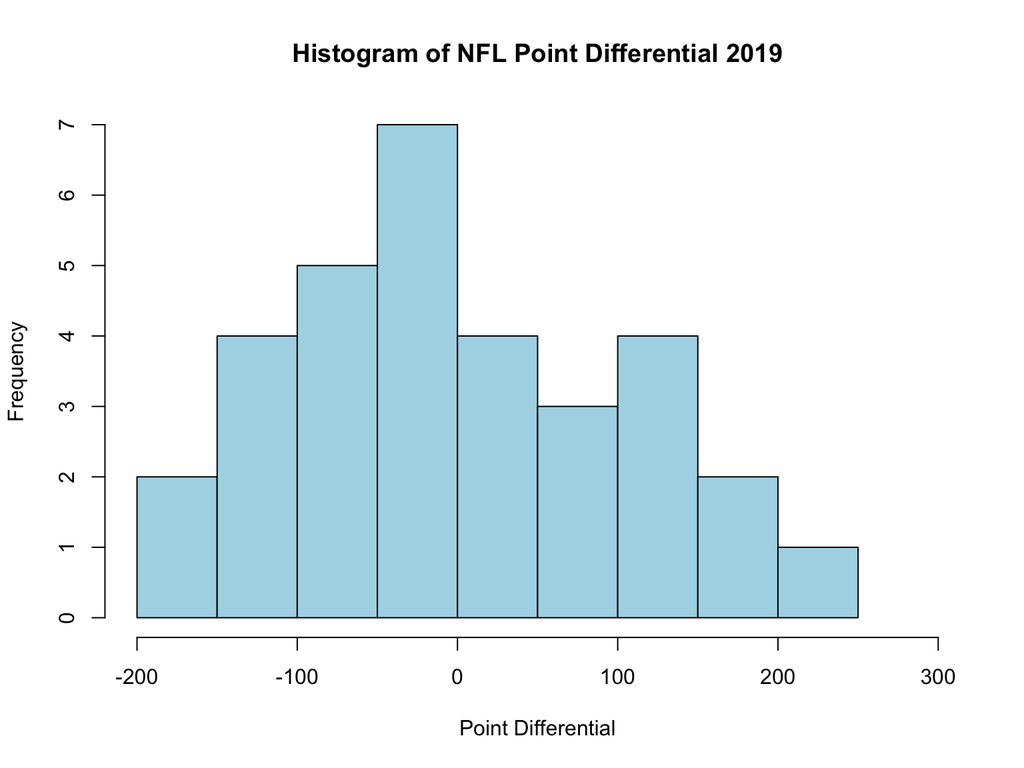

```r
hist(NFL$PD, breaks = 8, main = "Histogram of NFL Point Differential 2019",
     xlab = "Point Differential",
     col = "Light Blue", xlim = c(-200, 300))
```

PD = Point Differential

```r
# Linear Regression
NFL_WLPD = lm(NFL$W.L. ~ NFL$PD)
summary(NFL_WLPD)
```

```
##
## Call:
## lm(formula = NFL$W.L. ~ NFL$PD)
##
## Residuals:
##       Min        1Q    Median        3Q       Max
## -0.182555 -0.045230  0.002638  0.037029  0.211097
##
## Coefficients:
##              Estimate Std. Error t value Pr(>|t|)
## (Intercept) 0.5002812  0.0171115  29.237  < 2e-16 ***
## NFL$PD      0.0016130  0.0001614   9.992 4.66e-11 ***
## ---
## Signif. codes:  0 '***' 0.001 '**' 0.01 '*' 0.05 '.' 0.1 ' ' 1
##
## Residual standard error: 0.0968 on 30 degrees of freedom
## Multiple R-squared:  0.769,  Adjusted R-squared:  0.7613
## F-statistic: 99.85 on 1 and 30 DF,  p-value: 4.657e-11
```

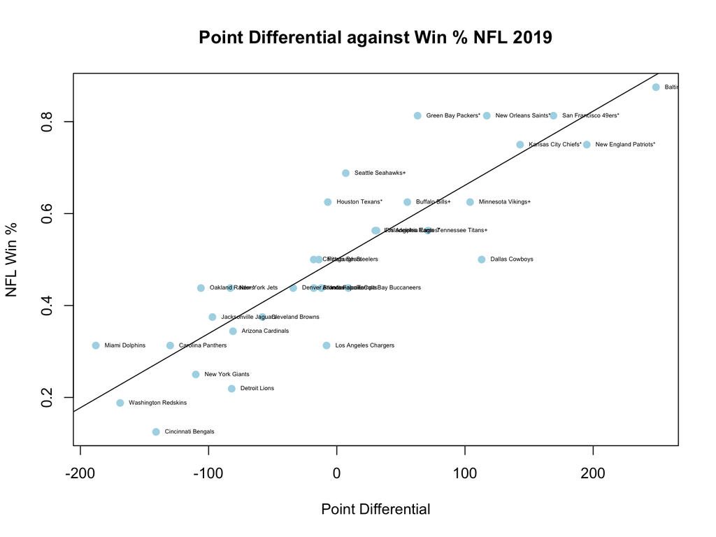

```r
plot(NFL$PD, NFL$W.L.,
     xlab = "Point Differential",
     ylab = "NFL Win %",
     main = "Point Differential against Win % NFL 2019",
     pch = 19,
     col = "light blue")
with(NFL, text(NFL$W.L. ~ NFL$PD,
               labels=Tm,
               pos=4,
               cex = .4))
abline(NFL_WLPD)
```

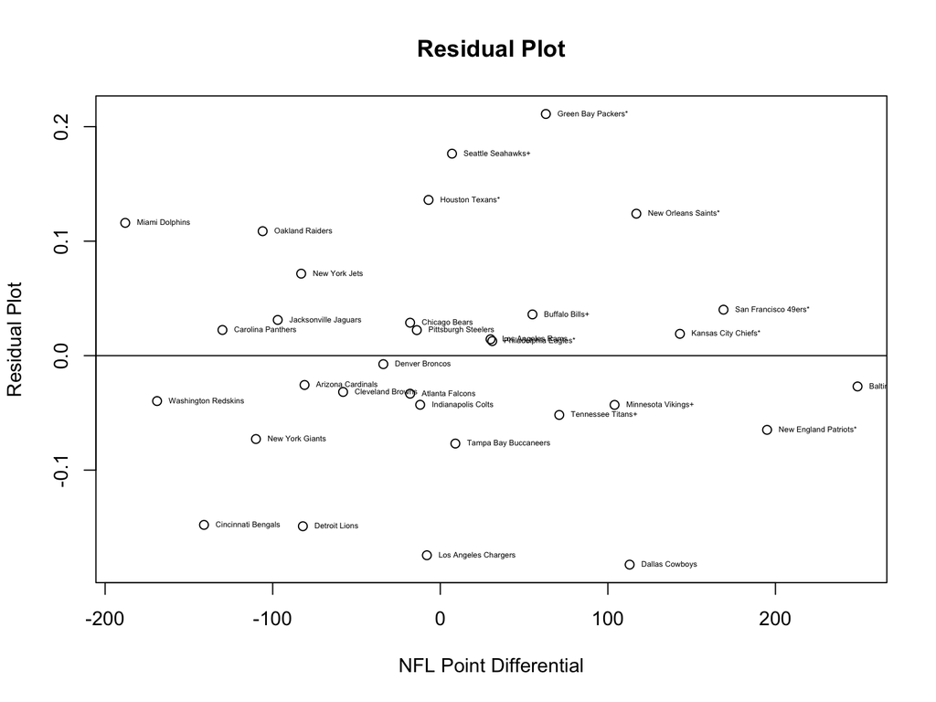

```r
res_WLPD = residuals(NFL_WLPD)
plot(NFL$PD,
     res_WLPD,
     main = "Residual Plot",
     xlab = "NFL Point Differential",
     ylab = "Residual Plot")
with(NFL, text(res_WLPD ~ NFL$PD, labels=Tm, pos=4, cex = .4))
abline(h = 0)
```

# Finding Clusters

```r
NFL_cluster = read.csv("cluster_NFL_reducedvariables4.csv")
head(NFL_cluster)
```

```
##                     Tm  W.L.   PD OSRS DSRS
## 1 Philadelphia Eagles* 0.563   31  0.7 -0.4
## 2       Dallas Cowboys 0.500  113  3.8  1.5
## 3      New York Giants 0.250 -110 -1.8 -6.1
## 4  Washington Redskins 0.188 -169 -6.3 -4.5
## 5   Green Bay Packers* 0.813   63  0.6  2.6
## 6   Minnesota Vikings+ 0.625  104  2.5  2.9
```

Over fitting a model.

Why I removed some variables?

Normalization (Z-score)

```r
z = NFL_cluster[, -c(1,1)]
m = apply(z,2,mean) # Find means
s = apply(z,2,sd) # Find Standard devs
z = scale(z,m,s) # Z-score
```

2 = columns

Euclidean Distance (distance formula with 4 variables)

```r
d = dist(z)
print(d, digits = 3)
```

```
##        1     2     3     4     5     6     7     8     9    10    11    12
## 2  1.223
## 3  2.599 3.408
## 4  3.328 4.222 1.333
## 5  1.511 1.845 4.008 4.561
## 6  1.216 0.798 3.748 4.424 1.125
## 7  2.033 2.670 3.257 3.148 2.334 2.361
## 8  2.280 2.967 0.639 1.498 3.730 3.344 2.872
## 9  1.954 1.621 4.472 5.264 1.188 1.145 3.292 4.165
## 10 0.784 1.597 2.016 2.698 2.181 1.786 1.908 1.605 2.638
## 11 1.617 1.874 2.229 3.435 2.882 2.382 3.450 2.042 2.772 1.565
## 12 2.389 3.291 0.451 1.307 3.731 3.555 2.978 0.731 4.258 1.802 2.201
## 13 2.619 1.947 5.131 5.921 1.839 1.564 3.774 4.770 0.820 3.243 3.341 4.939
## 14 0.860 1.453 3.117 3.914 1.228 1.251 2.557 2.873 1.457 1.432 1.752 2.860
## 15 0.655 0.922 3.035 3.725 1.376 0.820 2.066 2.638 1.654 1.052 1.855 2.810
## 16 1.668 2.482 1.057 1.899 3.076 2.771 2.485 0.726 3.531 1.003 1.645 0.841
## 17 2.784 2.173 5.311 5.848 1.888 1.611 3.187 4.874 1.671 3.323 3.939 5.107
## 18 1.920 2.246 3.926 4.076 1.597 1.696 1.081 3.525 2.512 2.168 3.498 3.659
## 19 1.991 3.014 1.973 1.808 2.911 2.955 1.486 1.790 3.797 1.585 2.906 1.674
## 20 3.371 4.302 1.118 1.659 4.636 4.571 4.036 1.738 5.133 2.896 2.887 1.173
## 21 3.826 2.992 6.215 7.113 3.134 2.816 5.076 5.861 2.033 4.425 4.208 6.064
## 22 1.854 2.438 3.228 3.214 2.169 2.133 0.272 2.816 3.080 1.741 3.275 2.947
## 23 1.318 2.138 1.471 2.152 2.708 2.377 2.106 1.061 3.199 0.591 1.663 1.243
## 24 3.067 3.801 1.253 0.745 4.377 4.078 2.934 1.103 4.988 2.353 3.125 1.268
## 25 0.478 1.541 2.658 3.373 1.405 1.403 2.127 2.407 1.925 0.965 1.700 2.388
## 26 0.711 0.703 3.188 3.877 1.318 0.563 2.097 2.783 1.552 1.229 1.968 2.997
## 27 0.861 1.781 1.909 2.512 2.235 1.923 1.770 1.527 2.794 0.338 1.740 1.698
## 28 2.045 3.045 1.396 1.377 3.191 3.123 1.972 1.253 3.953 1.505 2.614 1.108
## 29 2.122 1.464 4.596 5.424 1.590 1.160 3.467 4.242 0.519 2.742 2.791 4.414
## 30 1.791 2.543 2.667 2.601 2.477 2.390 0.598 2.279 3.359 1.488 3.039 2.401
## 31 1.923 2.988 1.060 1.672 3.146 3.122 2.562 1.176 3.772 1.485 2.099 0.709
## 32 1.439 1.997 1.934 2.343 2.729 2.240 1.715 1.394 3.253 0.809 2.117 1.800
##       13    14    15    16    17    18    19    20    21    22    23    24
## 2
## 3
## 4
## 5
## 6
## 7
## 8
```

[output cut: 41 more lines]

```
## 18
## 19
## 20
## 21
## 22
## 23
## 24
## 25
## 26 0.992
## 27 1.067 1.370
## 28 2.081 2.596 1.269
## 29 2.173 1.609 2.925 4.144
## 30 1.909 2.003 1.312 1.409 3.521
## 31 1.866 2.587 1.328 0.851 3.988 2.033
## 32 1.711 1.718 0.708 1.305 3.303 1.205 1.659
```

Example: team x and y = [(x.w%-y.w%)^2 + (x.PD-y.PD)^2 + (x.OSRS-y.OSRS)^2 + (x.DSRS-y.PDSRS)^2)]^.5 but calculate for every team against every other team

Cluster Dendrogram

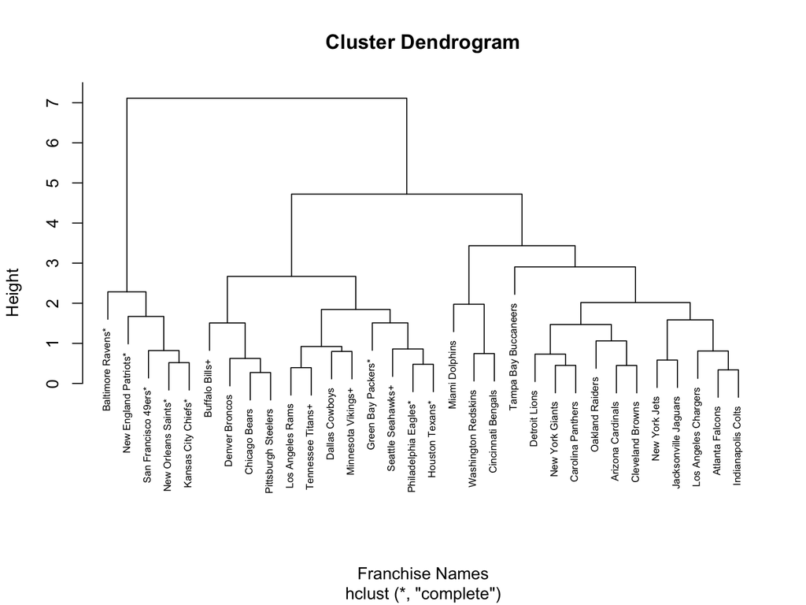

```r
hc_c = hclust(d)
plot(hc_c,labels = NFL_cluster$Tm, cex = .6, xlab = "Franchise Names")
```

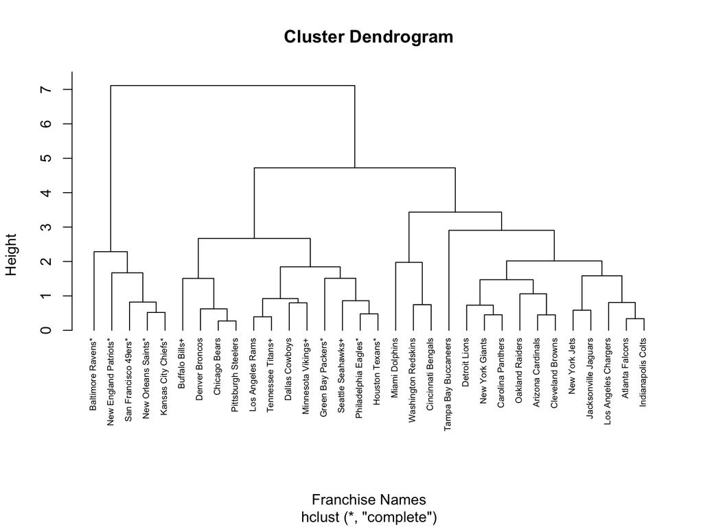

```r
plot(hc_c, hang = -1,
     labels = NFL_cluster$Tm,
     cex = .6,
     xlab = "Franchise Names")
```

Complete Linkage Used (means smaller clusters are used to create bigger ones) This means that the algorithm is finding the two, in this case, teams that have the closest overall z-scores.

Three Clusters?